# Spotify - Music of the Future

#### Duration models

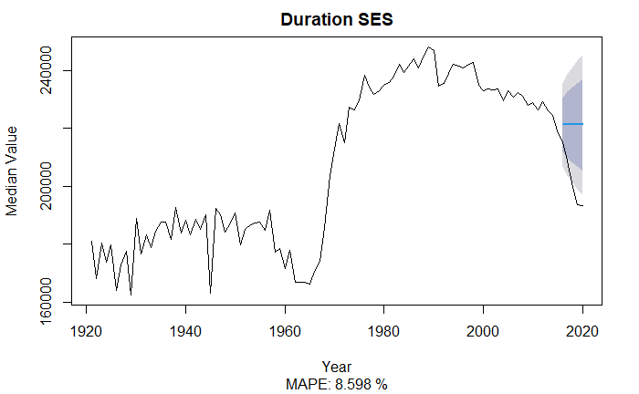

```r
duration = ts(as.numeric(feature_quantiles[,"duration_ms"]) , start=1921)
duration.train = subset(duration, start=1, end=nTrain)
duration.test = subset(duration, start = (nTrain+1), end =(nTrain+nTest))

#SES
duration.train.ses <- ses(duration.train, h=nTest)
duration.ses.mape = mape(duration.train.ses$mean, duration.test)
plot(duration.train.ses, main=paste("Duration", "SES"), sub=paste("MAPE:",round(duration.ses.mape*100, 3), "%"), xlab="Year", ylab="Median Value")
lines(duration)
```

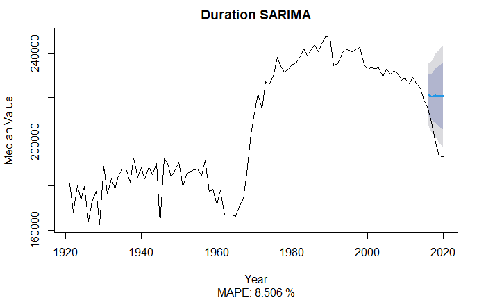

```r
#SARIMA
duration.sarima.model <- auto.arima(duration.train)
duration.sarima <- forecast(duration.sarima.model, h=nTest)
duration.sarima.mape = mape(duration.sarima$mean, duration.test)
plot(duration.sarima, main=paste("Duration", "SARIMA"), sub=paste("MAPE:", round(duration.sarima.mape*100, 3), "%"), xlab="Year", ylab="Median Value")
lines(duration)
```

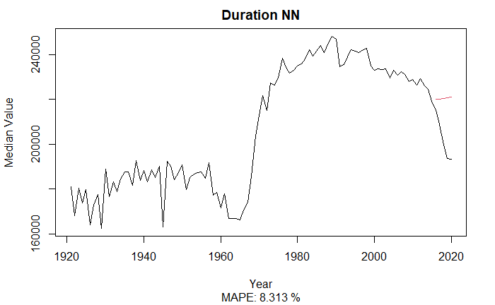

```r
#Neural Network
duration.train.nn <- elm(duration.train)
duration.nn.forecast <- forecast(duration.train.nn, h=nTest)
duration.nn.mape = mape(duration.nn.forecast$mean, duration.test)
plot(duration, main=paste("Duration", "NN"), sub=paste("MAPE:", round(duration.nn.mape*100, 3), "%"), xlab="Year", ylab="Median Value")
lines(ts(duration.nn.forecast$mean, start=1921+nTrain), col=2)
```

Here we see that the best method to predict future duration median values for the overall data set is through NN. Given that this best MAPE is roughly 8%, this feature can be fairly reliably forecast into the future.

#### Valence

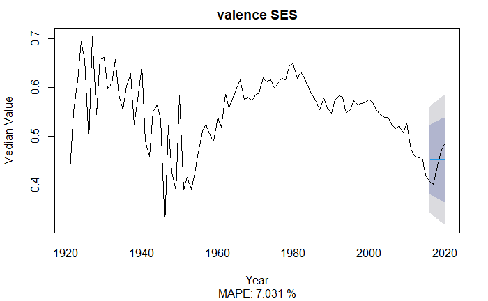

```r
valence = ts(as.numeric(feature_quantiles[,"valence"]) , start=1921)
valence.train = subset(valence, start=1, end=nTrain)
valence.test = subset(valence, start = (nTrain+1), end =(nTrain+nTest))

#SES
valence.train.ses <- ses(valence.train, h=nTest)
valence.ses.mape = mape(valence.train.ses$mean, valence.test)
plot(valence.train.ses, main=paste("valence", "SES"), sub=paste("MAPE:",round(valence.ses.mape*100, 3), "%"), xlab="Year", ylab="Median Value")
lines(valence)
```

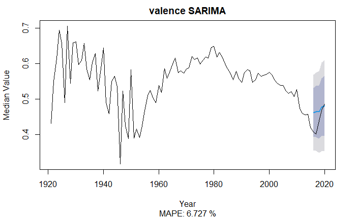

```r
#SARIMA
valence.sarima.model <- auto.arima(valence.train)
valence.sarima <- forecast(valence.sarima.model, h=nTest)
valence.sarima.mape = mape(valence.sarima$mean, valence.test)
plot(valence.sarima, main=paste("valence", "SARIMA"), sub=paste("MAPE:", round(valence.sarima.mape*100, 3), "%"), xlab="Year", ylab="Median Value")
lines(valence)
```

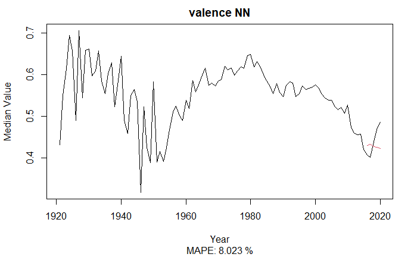

```r
#Neural Network
valence.train.nn <- elm(valence.train)
valence.nn.forecast <- forecast(valence.train.nn, h=nTest)
valence.nn.mape = mape(valence.nn.forecast$mean, valence.test)
plot(valence, main=paste("valence", "NN"), sub=paste("MAPE:", round(valence.nn.mape*100, 3), "%"), xlab="Year", ylab="Median Value")
lines(ts(valence.nn.forecast$mean, start=1921+nTrain), col=2)
```

##### Insights:

Relatively lower MAPE indicates that we can predict valence over time. The best model to use is the SARIMA model because it has the lowest MAPE at 6.7%.

#### Tempo model

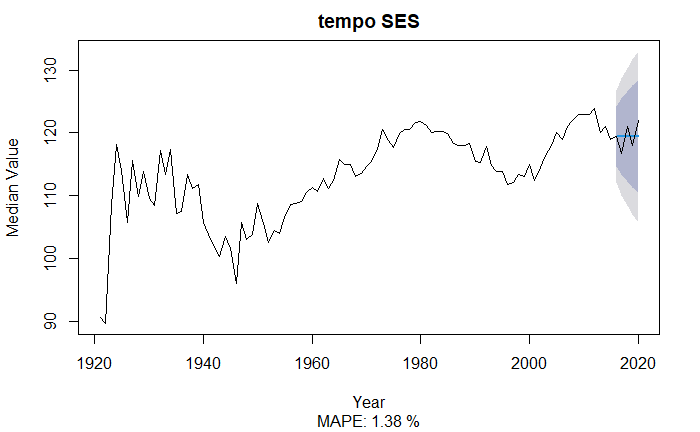

```r
tempo = ts(as.numeric(feature_quantiles[,"tempo"]) , start=1921)
tempo.train = subset(tempo, start=1, end=nTrain)
tempo.test = subset(tempo, start = (nTrain+1), end =(nTrain+nTest))

#SES
tempo.train.ses <- ses(tempo.train, h=nTest)
tempo.ses.mape = mape(tempo.train.ses$mean, tempo.test)
plot(tempo.train.ses, main=paste("tempo", "SES"), sub=paste("MAPE:",round(tempo.ses.mape*100, 3), "%"), xlab="Year", ylab="Median Value")
lines(tempo)
```

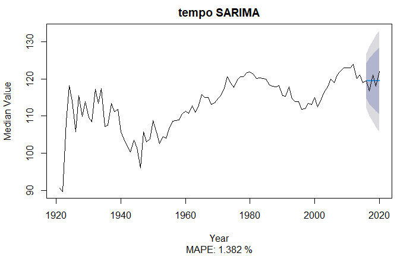

```r
#SARIMA
tempo.sarima.model <- auto.arima(tempo.train)
tempo.sarima <- forecast(tempo.sarima.model, h=nTest)
tempo.sarima.mape = mape(tempo.sarima$mean, tempo.test)
plot(tempo.sarima, main=paste("tempo", "SARIMA"), sub=paste("MAPE:", round(tempo.sarima.mape*100, 3), "%"), xlab="Year", ylab="Median Value")
lines(tempo)
```

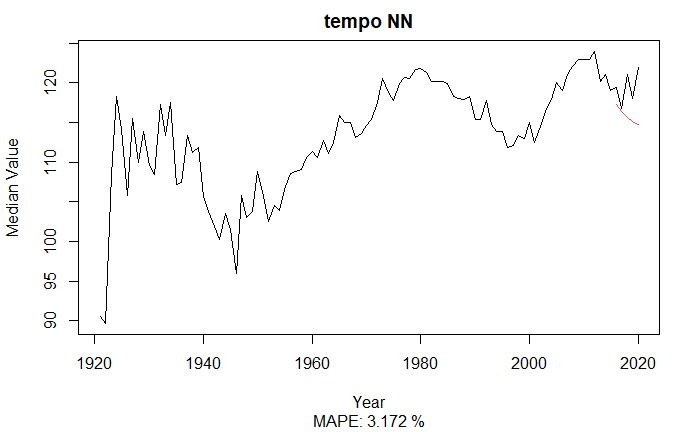

```r
#Neural Network
tempo.train.nn <- elm(tempo.train)
tempo.nn.forecast <- forecast(tempo.train.nn, h=nTest)
tempo.nn.mape = mape(tempo.nn.forecast$mean, tempo.test)
plot(tempo, main=paste("tempo", "NN"), sub=paste("MAPE:", round(tempo.nn.mape*100, 3), "%"), xlab="Year", ylab="Median Value")
lines(ts(tempo.nn.forecast$mean, start=1921+nTrain), col=2)
```

##### Insights:

Here we see that the best method to predict future tempo median values for the overall data set is through SES. Given that this best MAPE is roughly 1%, this feature can be fairly reliably forecast into the future.

#### Liveness

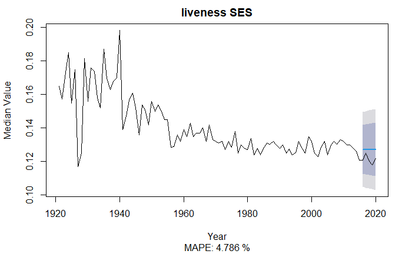

```r
liveness = ts(as.numeric(feature_quantiles[,"liveness"]) , start=1921)
liveness.train = subset(liveness, start=1, end=nTrain)
liveness.test = subset(liveness, start = (nTrain+1), end =(nTrain+nTest))

#SES
liveness.train.ses <- ses(liveness.train, h=nTest)
liveness.ses.mape = mape(liveness.train.ses$mean, liveness.test)
plot(liveness.train.ses, main=paste("liveness", "SES"), sub=paste("MAPE:",round(liveness.ses.mape*100, 3), "%"), xlab="Year", ylab="Median Value")
lines(liveness)
```

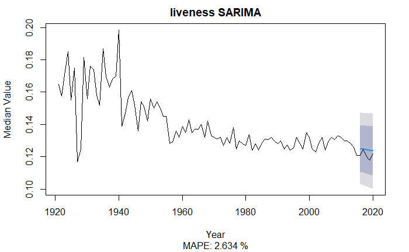

```r
#SARIMA
liveness.sarima.model <- auto.arima(liveness.train)
liveness.sarima <- forecast(liveness.sarima.model, h=nTest)
liveness.sarima.mape = mape(liveness.sarima$mean, liveness.test)
plot(liveness.sarima, main=paste("liveness", "SARIMA"), sub=paste("MAPE:", round(liveness.sarima.mape*100, 3), "%"), xlab="Year", ylab="Median Value")
lines(liveness)
```

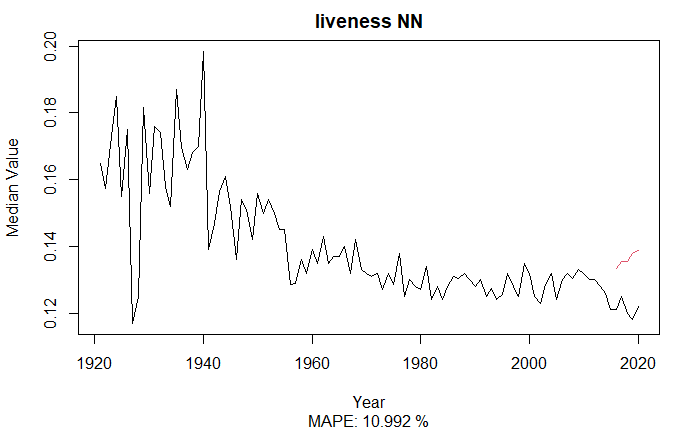

```r
#Neural Network
liveness.train.nn <- elm(liveness.train)
liveness.nn.forecast <- forecast(liveness.train.nn, h=nTest)
liveness.nn.mape = mape(liveness.nn.forecast$mean, liveness.test)
plot(liveness, main=paste("liveness", "NN"), sub=paste("MAPE:", round(liveness.nn.mape*100, 3), "%"), xlab="Year", ylab="Median Value")
lines(ts(liveness.nn.forecast$mean, start=1921+nTrain), col=2)
```

##### Insights:

Here we see that the best method to predict future liveness median values for the overall data set is through SARIMA Given that this best MAPE is roughly 2.6%, this feature can be fairly reliably forecast into the future.

#### Loudness

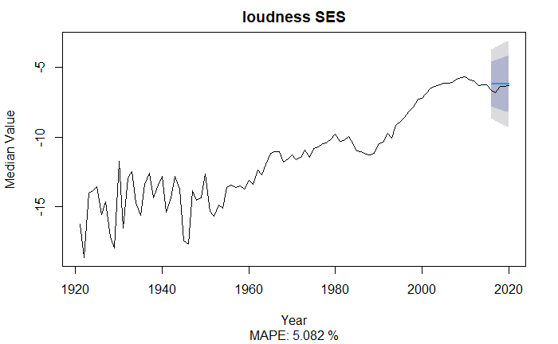

```r
loudness = ts(as.numeric(feature_quantiles[,"loudness"]) , start=1921)
loudness.train = subset(loudness, start=1, end=nTrain)
loudness.test = subset(loudness, start = (nTrain+1), end =(nTrain+nTest))

#SES
loudness.train.ses <- ses(loudness.train, h=nTest)
loudness.ses.mape = mape(loudness.train.ses$mean, loudness.test)
plot(loudness.train.ses, main=paste("loudness", "SES"), sub=paste("MAPE:",round(loudness.ses.mape*100, 3), "%"), xlab="Year", ylab="Median Value")
lines(loudness)
```

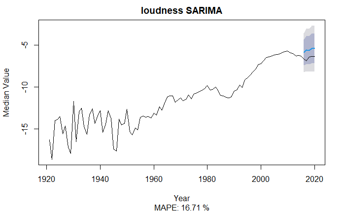

```r
#SARIMA
loudness.sarima.model <- auto.arima(loudness.train)
loudness.sarima <- forecast(loudness.sarima.model, h=nTest)
loudness.sarima.mape = mape(loudness.sarima$mean, loudness.test)
plot(loudness.sarima, main=paste("loudness", "SARIMA"), sub=paste("MAPE:", round(loudness.sarima.mape*100, 3), "%"), xlab="Year", ylab="Median Value")
lines(loudness)
```

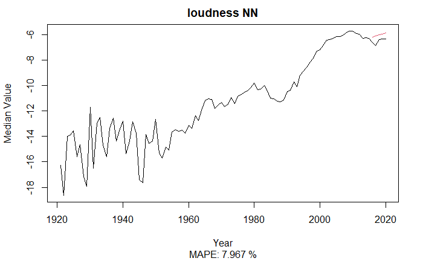

```r
#Neural Network
loudness.train.nn <- elm(loudness.train)
loudness.nn.forecast <- forecast(loudness.train.nn, h=nTest)
loudness.nn.mape = mape(loudness.nn.forecast$mean, loudness.test)
plot(loudness, main=paste("loudness", "NN"), sub=paste("MAPE:", round(loudness.nn.mape*100, 3), "%"), xlab="Year", ylab="Median Value")
lines(ts(loudness.nn.forecast$mean, start=1921+nTrain), col=2)
```

##### Insights:

Here we see that the best method to predict future loudness median values for the overall data set is through SES Given that this best MAPE is roughly 5%, this feature can be fairly reliably forecast into the future.

#### Linear Model for Overall Feature Median–> Most Popular Songs’ Feature Median

We will only consider models that had a low enough MAPEs (10% chosen as a threshold) in their best timeseries forecasting model.

Here, MAPE is the difference between the actual median for most popular songs and the predicted median.

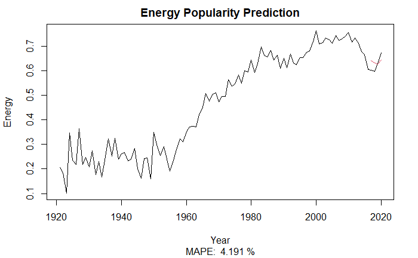

```r
#Energy
best_energy = ts(as.numeric(best_feature_quantiles[,"energy"]), start=1921, end=2020)
best_energy.train = subset(best_energy, start = 1, end = nTrain)
best_energy.test = subset(best_energy, start = nTrain+1, end = nTrain+nTest)
train_df = data.frame(best = best_energy.train, overall = energy.train)

best = best_energy.train
overall = energy.train

energy.lm <- lm(best ~ overall)
test_df <- data.frame(overall = energy.test)
best_energy.test.predict <- predict(energy.lm, newdata=test_df, interval="prediction")
best_energy_test_predict.mape <- mape(best_energy.test[1:length(best_energy.test)], best_energy.test.predict[,1])
plot(best_energy,xlab="Year", ylab="Energy", main=paste("Energy Popularity Prediction"), sub = paste("MAPE: ", round(best_energy_test_predict.mape*100, 3), "%"))
lines(ts(best_energy.test.predict[,1], start = 1921+nTrain+1, end = 2020), col = 2)
```

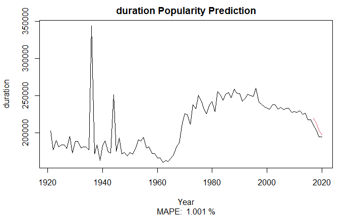

```r
#Duration
best_duration = ts(as.numeric(best_feature_quantiles[,"duration_ms"]), start=1921, end=2020)
best_duration.train = subset(best_duration, start = 1, end = nTrain)
best_duration.test = subset(best_duration, start = nTrain+1, end = nTrain+nTest)
train_df = data.frame(best = best_duration.train, overall = duration.train)

best = best_duration.train
overall = duration.train

duration.lm <- lm(best ~ overall)
test_df <- data.frame(overall = duration.test)
best_duration.test.predict <- predict(duration.lm, newdata=test_df, interval="prediction")
best_duration_test.predict.mape <- mape(best_duration.test[1:length(best_duration.test)], best_duration.test.predict[,1])
plot(best_duration,xlab="Year", ylab="duration", main=paste("duration Popularity Prediction"), sub = paste("MAPE: ", round(best_duration_test.predict.mape*100, 3), "%"))
lines(ts(best_duration.test.predict[,1], start = 1921+nTrain+1, end = 2020), col = 2)
```

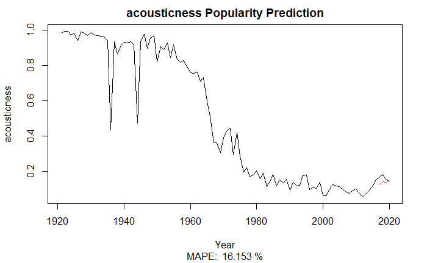

```r
# Acousticness
best_acousticness = ts(as.numeric(best_feature_quantiles[,"acousticness"]), start=1921, end=2020)
best_acousticness.train = subset(best_acousticness, start = 1, end = nTrain)
best_acousticness.test = subset(best_acousticness, start = nTrain+1, end = nTrain+nTest)
train_df = data.frame(best = best_acousticness.train, overall = acousticness.train)

best = best_acousticness.train
overall = acousticness.train

acousticness.lm <- lm(best ~ overall)
test_df <- data.frame(overall = acousticness.test)
best_acousticness.test.predict <- predict(acousticness.lm, newdata=test_df, interval="prediction")
best_acousticness_test.predict.mape <- mape(best_acousticness.test[1:length(best_acousticness.test)], best_acousticness.test.predict[,1])
plot(best_acousticness,xlab="Year", ylab="acousticness", main=paste("acousticness Popularity Prediction"), sub = paste("MAPE: ", round(best_acousticness_test.predict.mape*100, 3), "%"))
lines(ts(best_acousticness.test.predict[,1], start = 1921+nTrain+1, end = 2020), col = 2)
```

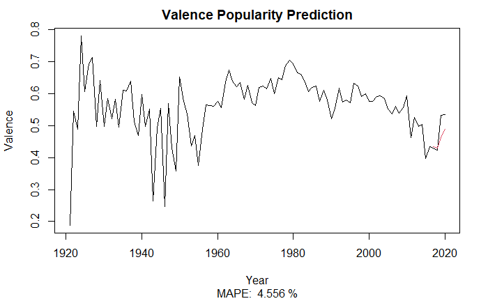

```r
#Valence
best_valence = ts(as.numeric(best_feature_quantiles[,"valence"]), start=1921, end=2020)
best_valence.train = subset(best_valence, start = 1, end = nTrain)
best_valence.test = subset(best_valence, start = nTrain+1, end = nTrain+nTest)
train_df = data.frame(best = best_valence.train, overall = valence.train)

best = best_valence.train
overall = valence.train

valence.lm <- lm(best ~ overall)
test_df <- data.frame(overall = valence.test)
best_valence.test.predict <- predict(valence.lm, newdata=test_df, interval="prediction")
best_valence_test.predict.mape <- mape(best_valence.test[1:length(best_valence.test)], best_valence.test.predict[,1])
plot(best_valence,xlab="Year", ylab="Valence", main=paste("Valence Popularity Prediction"), sub = paste("MAPE: ", round(best_valence_test.predict.mape*100, 3), "%"))
lines(ts(best_valence.test.predict[,1], start = 1921+nTrain+1, end = 2020), col = 2)
```

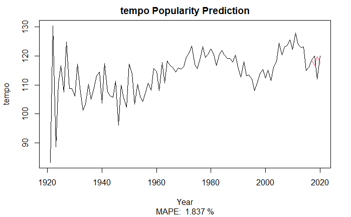

```r
#Tempo
best_tempo = ts(as.numeric(best_feature_quantiles[,"tempo"]), start=1921, end=2020)
best_tempo.train = subset(best_tempo, start = 1, end = nTrain)
best_tempo.test = subset(best_tempo, start = nTrain+1, end = nTrain+nTest)
train_df = data.frame(best = best_tempo.train, overall = tempo.train)

best = best_tempo.train
overall = tempo.train

tempo.lm <- lm(best ~ overall)
test_df <- data.frame(overall = tempo.test)
best_tempo.test.predict <- predict(tempo.lm, newdata=test_df, interval="prediction")
best_tempo_test.predict.mape <- mape(best_tempo.test[1:length(best_tempo.test)], best_tempo.test.predict[,1])
plot(best_tempo,xlab="Year", ylab="tempo", main=paste("tempo Popularity Prediction"), sub = paste("MAPE: ", round(best_tempo_test.predict.mape*100, 3), "%"))
lines(ts(best_tempo.test.predict[,1], start = 1921+nTrain+1, end = 2020), col = 2)
```

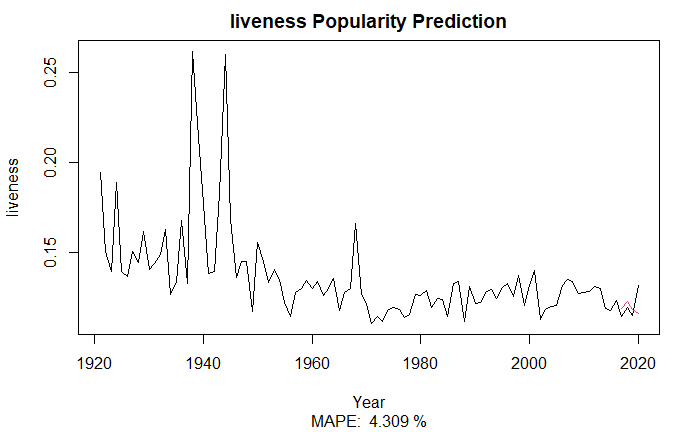

```r
#Liveness
best_liveness = ts(as.numeric(best_feature_quantiles[,"liveness"]), start=1921, end=2020)
best_liveness.train = subset(best_liveness, start = 1, end = nTrain)
best_liveness.test = subset(best_liveness, start = nTrain+1, end = nTrain+nTest)
train_df = data.frame(best = best_liveness.train, overall = liveness.train)

best = best_liveness.train
overall = liveness.train

liveness.lm <- lm(best ~ overall)
test_df <- data.frame(overall = liveness.test)
best_liveness.test.predict <- predict(liveness.lm, newdata=test_df, interval="prediction")
best_liveness_test.predict.mape <- mape(best_liveness.test[1:length(best_liveness.test)], best_liveness.test.predict[,1])
plot(best_liveness,xlab="Year", ylab="liveness", main=paste("liveness Popularity Prediction"), sub = paste("MAPE: ", round(best_liveness_test.predict.mape*100, 3), "%"))
lines(ts(best_liveness.test.predict[,1], start = 1921+nTrain+1, end = 2020), col = 2)
```

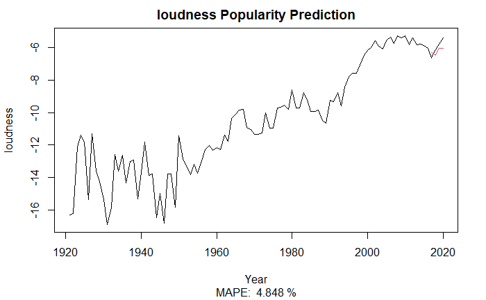

```r
#Loudness
best_loudness = ts(as.numeric(best_feature_quantiles[,"loudness"]), start=1921, end=2020)
best_loudness.train = subset(best_loudness, start = 1, end = nTrain)
best_loudness.test = subset(best_loudness, start = nTrain+1, end = nTrain+nTest)
train_df = data.frame(best = best_loudness.train, overall = loudness.train)

best = best_loudness.train
overall = loudness.train

loudness.lm <- lm(best ~ overall)
test_df <- data.frame(overall = loudness.test)
best_loudness.test.predict <- predict(loudness.lm, newdata=test_df, interval="prediction")
best_loudness_test.predict.mape <- mape(best_loudness.test[1:length(best_loudness.test)], best_loudness.test.predict[,1])
plot(best_loudness,xlab="Year", ylab="loudness", main=paste("loudness Popularity Prediction"), sub = paste("MAPE: ", round(best_loudness_test.predict.mape*100, 3), "%"))
lines(ts(best_loudness.test.predict[,1], start = 1921+nTrain+1, end = 2020), col = 2)
```

##### Insights:

**Energy**: A low MAPE around 4% indicates that we can use the overall trend to identify the energy of popular songs

**Duration**: A low MAPE around 1% indicates that we can use the overall trend to identify the duration of popular songs

**Acousticness**: A high MAPE around 16% indicates that we can not use the overall trend to identify the acousticness of popular songs. We will not include predictions for acousticness of popular songs.

**Valence**: A low MAPE around 4.6% indicates that we can use the overall trend to identify the valence of popular songs

**Tempo**: A low MAPE around 2% indicates that we can use the overall trend to identify the tempo of popular songs

**Liveness**: A low MAPE around 4.3% indicates that we can use the overall trend to identify the liveness of popular songs

**Loudness**: A low MAPE around 5% indicates that we can use the overall trend to identify the loudness of popular songs

### Predict features for the overall market trends for the next five years

Only including features whose trained linear models had a MAPE below 10%, as these are the features whose most popular medians will be most reliably predicted by their forecast overall values. Using the best timeseries method seen for each feature.

#### Energy: SES Model

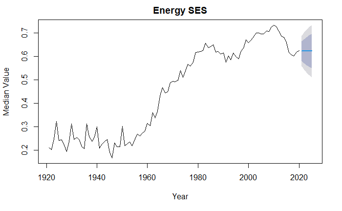

```r
energy.ses <- ses(energy, h=nTest)
plot(energy.ses, main=paste("Energy", "SES"), xlab="Year", ylab="Median Value")
lines(energy)
```

#### Duration: NN Model

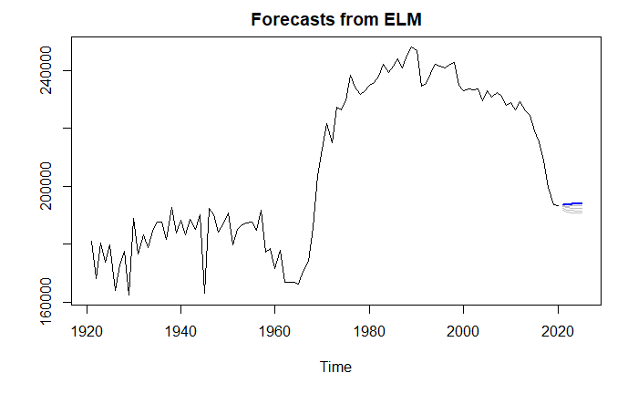

```r
duration.nn <- elm(duration)
duration.nn.predict <- forecast(duration.nn, h=nTest)
plot(duration.nn.predict, main=paste("Duration", "NN"), xlab="Year", ylab="Median Value")
```

#### Tempo: SES Model

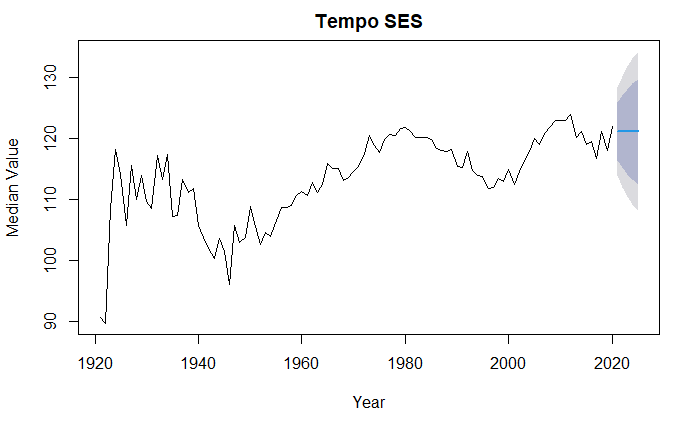

```r
tempo.ses <- ses(tempo, h=nTest)
plot(tempo.ses, main=paste("Tempo", "SES"), xlab="Year", ylab="Median Value")
lines(tempo)
```

#### Valence: SARIMA Model

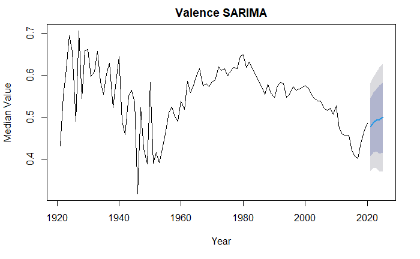

```r
valence.sarima <- auto.arima(valence)
valence.sarima.predict <- forecast(valence.sarima, h=nTest)
plot(valence.sarima.predict, main=paste("Valence", "SARIMA"), xlab="Year", ylab="Median Value")
lines(valence)
```

#### Liveness: SARIMA Model

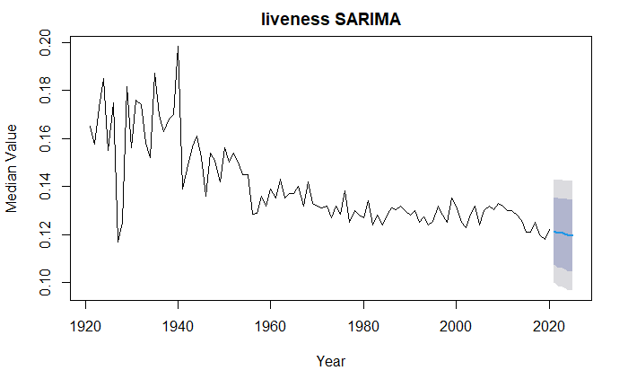

```r
liveness.sarima <- auto.arima(liveness)
liveness.sarima.predict <- forecast(liveness.sarima, h=nTest)
plot(liveness.sarima.predict, main=paste("liveness", "SARIMA"), xlab="Year", ylab="Median Value")
lines(liveness)
```

#### Loudness: SES Model

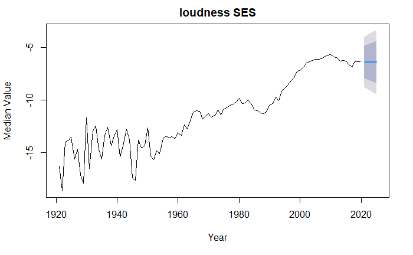

```r
loudness.ses <- ses(loudness, h=nTest)
plot(loudness.ses, main=paste("loudness", "SES"), xlab="Year", ylab="Median Value")
lines(loudness)
```

### Now, we predict the median values for the *most popular songs* for this set of features

The forecast overall median values and linear model predicting the most popular median values for each feature given overall median value will be used to predict the future median values for popular songs for each feature.

#### Energy

```r
best = best_energy
overall = energy


energy.lm <- lm(best ~ overall)
predict_df <- data.frame(overall = energy.ses$mean)
energy.predict <- predict(energy.lm, newdata=predict_df, interval="prediction")

smallest = min(min(best), min(overall))
biggest = max(max(best), max(overall))
plot(energy, xlab="Year", ylab="Median Value", ylim=c(smallest, biggest), main="Most Popular Song's Energy Feature Prediction", sub=paste("Projected median feature value for most popular songs:", paste(round(energy.ses$mean, 3), collapse=",") ))
lines(best_energy, col = 2)
```

[figure not shown]

```r
lines(ts(energy.predict[,1], start=2020+1, end=2020+nTest), col = 3)
legend("bottomright", lty=1, col=c(1,2,3), legend=c("Overall", "Most Popular", "Most Popular Projection"))
```

#### Duration

```r
best = best_duration
overall = duration

duration.lm <- lm(best ~ overall)
predict_df <- data.frame(overall = duration.nn.predict$mean)
duration.predict <- predict(duration.lm, newdata=predict_df, interval="prediction")

smallest = min(min(best), min(overall))
biggest = max(max(best), max(overall))
plot(duration, xlab="Year", ylab="Median Value", ylim=c(smallest, biggest), main="Most Popular Song's Duration Feature Prediction", sub=paste("Projected median feature value for most popular songs:", paste(round(duration.nn.predict$mean), collapse=",") ))
lines(best_duration, col = 2)
```

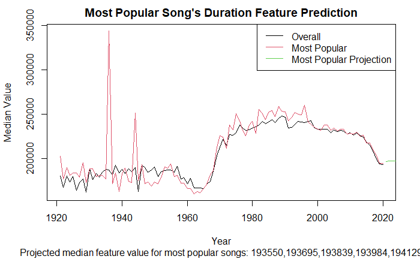

```r
lines(ts(duration.predict[,1], start=2020+1, end=2020+nTest), col = 3)
legend("topright", lty=1, col=c(1,2,3), legend=c("Overall", "Most Popular", "Most Popular Projection"))
```

#### Tempo

```r
best = best_tempo
overall = tempo

tempo.lm <- lm(best ~ overall)
predict_df <- data.frame(overall = tempo.ses$mean)
tempo.predict <- predict(tempo.lm, newdata=predict_df, interval="prediction")


smallest = min(min(best), min(overall))
biggest = max(max(best), max(overall))
plot(tempo, xlab="Year", ylab="Median Value", ylim=c(smallest, biggest), main="Most Popular Song's Tempo Feature Prediction", sub=paste("Projected median feature value for most popular songs:", paste(round(tempo.ses$mean), collapse=",") ))
lines(best_tempo, col = 2)
```

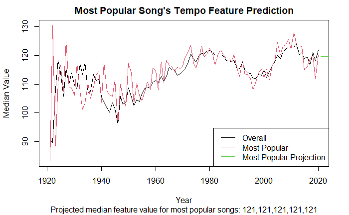

```r
lines(ts(tempo.predict[,1], start=2020+1, end=2020+nTest), col = 3)
legend("bottomright", lty=1, col=c(1,2,3), legend=c("Overall", "Most Popular", "Most Popular Projection"))
```

#### Valence

```r
best = best_valence
overall = valence

valence.lm <- lm(best ~ overall)
predict_df <- data.frame(overall = valence.sarima.predict$mean)
valence.predict <- predict(valence.lm, newdata=predict_df, interval="prediction")


smallest = min(min(best), min(overall))
biggest = max(max(best), max(overall))
plot(valence, xlab="Year", ylab="Median Value", ylim=c(smallest, biggest), main="Most Popular Song's valence Feature Prediction", sub=paste("Projected median feature value for most popular songs:", paste(round(valence.sarima.predict$mean,3), collapse=",") ))
lines(best_valence, col = 2)
```

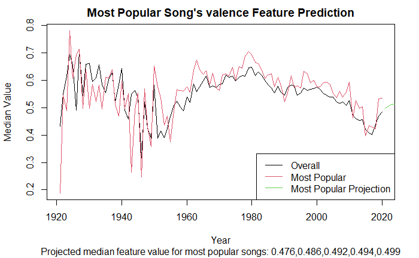

```r
lines(ts(valence.predict[,1], start=2020+1, end=2020+nTest), col = 3)
legend("bottomright", lty=1, col=c(1,2,3), legend=c("Overall", "Most Popular", "Most Popular Projection"))
```

#### Liveness

```r
best = best_liveness
overall = liveness

liveness.lm <- lm(best ~ overall)
predict_df <- data.frame(overall = liveness.sarima.predict$mean)
liveness.predict <- predict(liveness.lm, newdata=predict_df, interval="prediction")

smallest = min(min(best), min(overall))
biggest = max(max(best), max(overall))
plot(liveness, xlab="Year", ylab="Median Value", ylim=c(smallest, biggest), main="Most Popular Song's Liveness Feature Prediction", sub=paste("Projected median feature value for most popular songs:", paste(round(liveness.sarima.predict$mean,3), collapse=",") ))
lines(best_liveness, col = 2)
```

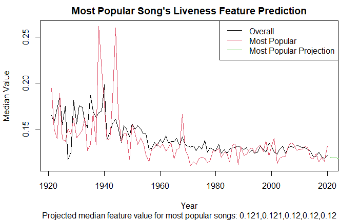

```r
lines(ts(liveness.predict[,1], start=2020+1, end=2020+nTest), col = 3)
legend("topright", lty=1, col=c(1,2,3), legend=c("Overall", "Most Popular", "Most Popular Projection"))
```

#### Loudness

```r
best = best_loudness
overall = loudness

loudness.lm <- lm(best ~ overall)
predict_df <- data.frame(overall = loudness.ses$mean)
loudness.predict <- predict(loudness.lm, newdata=predict_df, interval="prediction")

smallest = min(min(best), min(overall))
biggest = max(max(best), max(overall))
plot(loudness, xlab="Year", ylab="Median Value", ylim=c(smallest, biggest), main="Most Popular Song's Loudness Feature Prediction", sub=paste("Projected median feature value for most popular songs:", paste(round(loudness.ses$mean,1), collapse=",") ))
lines(best_loudness, col = 2)
```

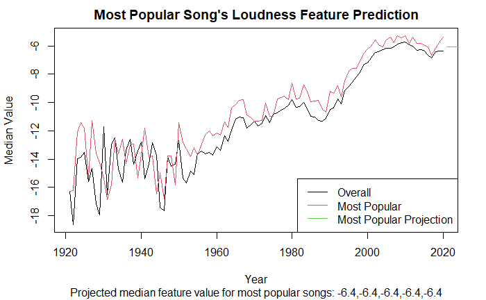

```r
lines(ts(loudness.predict[,1], start=2020+1, end=2020+nTest), col = 3)
legend("bottomright", lty=1, col=c(1,2,3), legend=c("Overall", "Most Popular", "Most Popular Projection"))
```

### Popularity Predictions

#### Transformations to create dataset for predictions

Look at distribution of main dataset by year

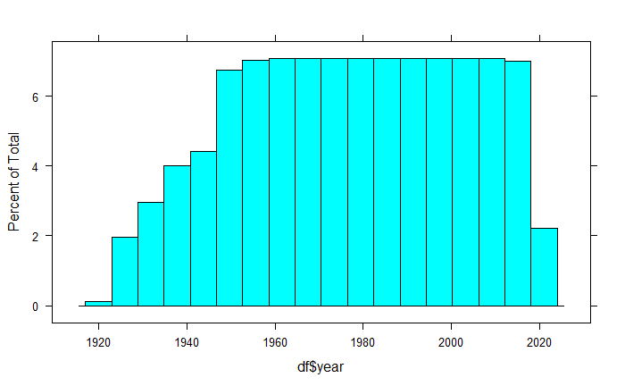

```r
histogram(df$year)
```

The dataset has an even quantity of data for each year since 1960 (except for 2020). As a result, in order to reduce the burden of the dataset for predictions, we truncate the dataset to rows on and after the year 1990.

```r
# Apply transformations to create a prediction dataset

# Truncate to years on or after 1990
predict_set = df[df$year >= 1990,]

# Remove uneeded columns
predict_set = predict_set[,!(colnames(predict_set)  %in% c("id","release_date","name", "artists"))]
glimpse(predict_set)
```

```
Rows: 61,656
Columns: 16
$ acousticness     <dbl> 7.75e-01, 1.85e-01, 5.03e-06, 9.75e-01, 5.59e-01, 3.96e-01, 3.25e-01, 6.46e-01, 9.72e-04, 7.66e-01, 9.83e-02, 2.01e-01,...
$ danceability     <dbl> 0.656, 0.275, 0.289, 0.229, 0.120, 0.463, 0.637, 0.661, 0.372, 0.378, 0.503, 0.564, 0.870, 0.369, 0.896, 0.298, 0.861, ...
$ duration_ms      <int> 303507, 308112, 260933, 219600, 239133, 298027, 251773, 190667, 283960, 321960, 269507, 287373, 192000, 313760, 272200,...
$ energy           <dbl> 0.6440, 0.5980, 0.8870, 0.0723, 0.4190, 0.6240, 0.5110, 0.4600, 0.8270, 0.1490, 0.8020, 0.6180, 0.3230, 0.9800, 0.7150,...
$ explicit         <int> 0, 0, 0, 0, 0, 0, 0, 0, 0, 0, 0, 0, 0, 0, 0, 0, 0, 0, 1, 0, 0, 0, 0, 0, 0, 0, 0, 0, 0, 0, 0, 0, 0, 0, 0, 0, 0, 0, 0, 0,...
$ instrumentalness <dbl> 4.16e-01, 1.11e-05, 8.61e-01, 1.76e-04, 0.00e+00, 1.31e-05, 0.00e+00, 5.93e-03, 3.08e-01, 8.99e-01, 0.00e+00, 0.00e+00,...
$ key              <chr> "6", "3", "1", "9", "0", "3", "10", "11", "2", "5", "5", "4", "0", "7", "7", "11", "1", "5", "5", "7", "7", "7", "5", "...
$ liveness         <dbl> 0.1200, 0.1490, 0.2930, 0.0870, 0.4860, 0.0712, 0.0607, 0.0913, 0.4060, 0.0993, 0.1810, 0.3660, 0.1040, 0.1550, 0.0433,...
$ loudness         <dbl> -12.878, -6.757, -14.387, -17.460, -11.881, -9.174, -11.991, -10.545, -9.546, -22.628, -9.530, -6.074, -16.507, -3.031,...
$ mode             <int> 0, 1, 1, 1, 1, 1, 0, 1, 1, 1, 1, 0, 0, 1, 1, 0, 1, 0, 0, 1, 1, 1, 1, 1, 1, 1, 0, 1, 1, 1, 1, 1, 1, 1, 1, 0, 1, 0, 1, 1,...
$ popularity       <int> 35, 35, 40, 35, 37, 44, 37, 33, 33, 44, 34, 36, 37, 36, 37, 36, 32, 43, 36, 33, 44, 32, 32, 35, 40, 31, 38, 32, 34, 32,...
$ speechiness      <dbl> 0.0377, 0.0305, 0.0963, 0.0402, 0.0427, 0.0437, 0.0296, 0.0347, 0.0472, 0.0370, 0.0392, 0.0319, 0.4070, 0.0476, 0.0917,...
$ tempo            <dbl> 120.942, 180.130, 148.655, 79.303, 73.289, 205.275, 137.849, 116.687, 132.051, 140.432, 103.297, 121.841, 78.605, 122.5...
$ valence          <dbl> 0.9430, 0.1980, 0.4780, 0.0738, 0.2840, 0.5470, 0.5730, 0.8910, 0.6590, 0.4120, 0.2650, 0.3580, 0.9400, 0.6520, 0.7200,...
$ year             <dbl> 1990, 1990, 1990, 1990, 1990, 1990, 1990, 1990, 1990, 1990, 1990, 1990, 1990, 1990, 1990, 1990, 1990, 1990, 1990, 1990,...
$ key_val          <chr> "F♯,G♭", "D♯,E♭", "C♯,D♭", "A", "C", "D♯,E♭", "A♯,B♭", "B", "D", "F", "F", "E", "C", "G", "G", "B", "C♯,D♭", "F", "F", ...
```

Key is categorical - need to turn the feature into multiple columns of dummy variables

```r
# Look at number of unique Keys
unique(predict_set$key)
```

```
 [1] "6"  "3"  "1"  "9"  "0"  "10" "11" "2"  "5"  "4"  "7"  "8"
```

```r
# Create dummy variables for each unique key value.
# remove_first_dummy set to true to remove first dummy variable created - done to avoid multicollinearity in a multiple regression model.
predict_set <- fastDummies::dummy_cols(predict_set,select_columns = "key", remove_first_dummy = TRUE)
predict_set = select(predict_set, -c(key,key_val))
head(predict_set)
```

|  | acousticness | danceability | duration_ms | energy | explicit | instrumentalness | liveness | loudness | mode | popularity | speechiness | tempo | valence | year | key_1 | key_2 | key_3 | key_4 | key_5 | key_6 | key_7 | key_8 | key_9 | key_10 | key_11 |
| --- | --- | --- | --- | --- | --- | --- | --- | --- | --- | --- | --- | --- | --- | --- | --- | --- | --- | --- | --- | --- | --- | --- | --- | --- | --- |
| 1 | 7.75e-01 | 0.656 | 303507 | 0.6440 | 0 | 4.16e-01 | 0.1200 | -12.878 | 0 | 35 | 0.0377 | 120.942 | 0.9430 | 1990 | 0 | 0 | 0 | 0 | 0 | 1 | 0 | 0 | 0 | 0 | 0 |
| 2 | 1.85e-01 | 0.275 | 308112 | 0.5980 | 0 | 1.11e-05 | 0.1490 | -6.757 | 1 | 35 | 0.0305 | 180.130 | 0.1980 | 1990 | 0 | 0 | 1 | 0 | 0 | 0 | 0 | 0 | 0 | 0 | 0 |
| 3 | 5.03e-06 | 0.289 | 260933 | 0.8870 | 0 | 8.61e-01 | 0.2930 | -14.387 | 1 | 40 | 0.0963 | 148.655 | 0.4780 | 1990 | 1 | 0 | 0 | 0 | 0 | 0 | 0 | 0 | 0 | 0 | 0 |
| 4 | 9.75e-01 | 0.229 | 219600 | 0.0723 | 0 | 1.76e-04 | 0.0870 | -17.460 | 1 | 35 | 0.0402 | 79.303 | 0.0738 | 1990 | 0 | 0 | 0 | 0 | 0 | 0 | 0 | 0 | 1 | 0 | 0 |
| 5 | 5.59e-01 | 0.120 | 239133 | 0.4190 | 0 | 0.00e+00 | 0.4860 | -11.881 | 1 | 37 | 0.0427 | 73.289 | 0.2840 | 1990 | 0 | 0 | 0 | 0 | 0 | 0 | 0 | 0 | 0 | 0 | 0 |
| 6 | 3.96e-01 | 0.463 | 298027 | 0.6240 | 0 | 1.31e-05 | 0.0712 | -9.174 | 1 | 44 | 0.0437 | 205.275 | 0.5470 | 1990 | 0 | 0 | 1 | 0 | 0 | 0 | 0 | 0 | 0 | 0 | 0 |

#### Split into training and prediction set (80/20 split)

```r
# 80% as train_set
train_size <- floor(0.80 * nrow(predict_set))

set.seed(123)
train_ind <- sample(seq_len(nrow(predict_set)), size = train_size)

predict_set.train <- predict_set[train_ind, ]
predict_set.test <- predict_set[-train_ind, ]

# Look at number of prediction/training set rows
nrow(predict_set.train)
```

```
[1] 49324
```

```r
nrow(predict_set.test)
```

```
[1] 12332
```

```r
# Snapshot of training set
glimpse(predict_set.train)
```

```
Rows: 49,324
Columns: 25
$ acousticness     <dbl> 4.02e-05, 1.74e-01, 7.42e-01, 8.96e-01, 5.47e-03, 1.20e-03, 1.14e-01, 1.07e-01, 2.49e-01, 4.35e-01, 1.23e-02, 7.57e-01,...
$ danceability     <dbl> 0.295, 0.608, 0.636, 0.492, 0.454, 0.491, 0.746, 0.731, 0.764, 0.622, 0.612, 0.275, 0.410, 0.674, 0.198, 0.550, 0.618, ...
$ duration_ms      <int> 239387, 248387, 209293, 162261, 243467, 345253, 206453, 177847, 188160, 287427, 210773, 221733, 223693, 144090, 122723,...
$ energy           <dbl> 0.924000, 0.572000, 0.543000, 0.173000, 0.672000, 0.766000, 0.892000, 0.650000, 0.501000, 0.253000, 0.494000, 0.366000,...
$ explicit         <int> 1, 0, 0, 0, 0, 0, 0, 1, 0, 0, 0, 0, 0, 1, 0, 0, 0, 0, 1, 0, 1, 0, 0, 0, 0, 0, 0, 0, 1, 0, 0, 0, 0, 0, 0, 0, 1, 0, 0, 0,...
$ instrumentalness <dbl> 4.62e-03, 0.00e+00, 4.78e-04, 0.00e+00, 3.21e-06, 4.81e-04, 0.00e+00, 0.00e+00, 2.49e-06, 4.71e-01, 2.70e-05, 0.00e+00,...
$ liveness         <dbl> 0.3770, 0.2370, 0.0391, 0.1090, 0.1790, 0.1090, 0.0619, 0.1240, 0.3870, 0.0941, 0.1020, 0.1210, 0.1360, 0.1150, 0.1100,...
$ loudness         <dbl> -3.407, -6.099, -12.007, -11.240, -8.596, -3.967, -3.905, -5.286, -8.370, -14.360, -10.365, -10.305, -9.006, -3.813, -3...
$ mode             <int> 1, 0, 0, 0, 0, 0, 1, 1, 1, 1, 0, 1, 1, 0, 1, 0, 1, 1, 1, 0, 0, 0, 0, 1, 0, 0, 1, 0, 0, 1, 0, 1, 1, 0, 0, 0, 1, 1, 1, 1,...
$ popularity       <int> 64, 63, 29, 59, 54, 46, 53, 80, 29, 60, 50, 43, 41, 74, 62, 58, 45, 53, 57, 48, 61, 45, 73, 36, 41, 48, 57, 37, 33, 40,...
$ speechiness      <dbl> 0.0678, 0.0310, 0.0622, 0.0406, 0.0292, 0.0291, 0.0303, 0.2710, 0.0283, 0.0331, 0.0606, 0.0360, 0.0274, 0.1410, 0.0432,...
$ tempo            <dbl> 171.941, 98.989, 101.591, 125.058, 114.446, 128.101, 91.518, 154.968, 127.224, 92.584, 147.964, 122.604, 173.878, 160.0...
$ valence          <dbl> 0.2190, 0.2260, 0.8830, 0.3360, 0.7350, 0.2100, 0.9720, 0.6050, 0.7020, 0.3360, 0.1470, 0.1200, 0.7940, 0.4430, 0.0674,...
$ year             <dbl> 2015, 2018, 1991, 2019, 2004, 2004, 2008, 2019, 1991, 2012, 2013, 2009, 1994, 2019, 2016, 2005, 1997, 1997, 2003, 2002,...
$ key_1            <int> 0, 0, 0, 0, 0, 0, 0, 0, 0, 0, 0, 0, 0, 0, 0, 0, 0, 1, 0, 0, 0, 0, 1, 0, 1, 0, 0, 0, 0, 0, 0, 0, 1, 1, 0, 0, 0, 0, 0, 0,...
$ key_2            <int> 0, 0, 0, 0, 0, 0, 0, 0, 1, 1, 0, 0, 0, 0, 0, 0, 0, 0, 1, 0, 0, 0, 0, 0, 0, 0, 0, 0, 0, 0, 0, 0, 0, 0, 0, 0, 0, 0, 0, 0,...
$ key_3            <int> 0, 0, 0, 0, 0, 0, 0, 0, 0, 0, 0, 0, 0, 0, 0, 0, 0, 0, 0, 0, 0, 0, 0, 0, 0, 0, 0, 0, 0, 0, 0, 0, 0, 0, 0, 0, 0, 0, 0, 0,...
$ key_4            <int> 0, 1, 0, 0, 0, 0, 0, 0, 0, 0, 0, 0, 0, 0, 0, 0, 0, 0, 0, 0, 0, 0, 0, 0, 0, 1, 0, 0, 0, 0, 0, 0, 0, 0, 1, 0, 0, 1, 0, 0,...
$ key_5            <int> 1, 0, 1, 0, 0, 0, 0, 0, 0, 0, 0, 0, 0, 0, 0, 1, 0, 0, 0, 1, 0, 1, 0, 0, 0, 0, 0, 0, 0, 0, 0, 0, 0, 0, 0, 0, 0, 0, 0, 0,...
$ key_6            <int> 0, 0, 0, 0, 1, 0, 0, 0, 0, 0, 0, 0, 1, 0, 1, 0, 0, 0, 0, 0, 1, 0, 0, 0, 0, 0, 0, 1, 0, 0, 1, 0, 0, 0, 0, 0, 1, 0, 0, 0,...
$ key_7            <int> 0, 0, 0, 0, 0, 0, 0, 0, 0, 0, 0, 0, 0, 0, 0, 0, 0, 0, 0, 0, 0, 0, 0, 0, 0, 0, 0, 0, 0, 1, 0, 1, 0, 0, 0, 0, 0, 0, 1, 0,...
$ key_8            <int> 0, 0, 0, 0, 0, 0, 0, 0, 0, 0, 0, 0, 0, 0, 0, 0, 0, 0, 0, 0, 0, 0, 0, 0, 0, 0, 0, 0, 0, 0, 0, 0, 0, 0, 0, 0, 0, 0, 0, 1,...
$ key_9            <int> 0, 0, 0, 0, 0, 0, 0, 0, 0, 0, 0, 0, 0, 0, 0, 0, 0, 0, 0, 0, 0, 0, 0, 0, 0, 0, 0, 0, 0, 0, 0, 0, 0, 0, 0, 0, 0, 0, 0, 0,...
$ key_10           <int> 0, 0, 0, 0, 0, 0, 1, 0, 0, 0, 0, 1, 0, 0, 0, 0, 0, 0, 0, 0, 0, 0, 0, 0, 0, 0, 0, 0, 0, 0, 0, 0, 0, 0, 0, 1, 0, 0, 0, 0,...
$ key_11           <int> 0, 0, 0, 1, 0, 0, 0, 0, 0, 0, 1, 0, 0, 1, 0, 0, 0, 0, 0, 0, 0, 0, 0, 1, 0, 0, 0, 0, 1, 0, 0, 0, 0, 0, 0, 0, 0, 0, 0, 0,...
```

```r
summary(predict_set.train)
```

```
  acousticness     danceability     duration_ms          energy          explicit      instrumentalness       liveness         loudness
 Min.   :0.0000   Min.   :0.0000   Min.   :  30080   Min.   :0.0000   Min.   :0.0000   Min.   :0.0000000   Min.   :0.0000   Min.   :-60.000
 1st Qu.:0.0212   1st Qu.:0.4710   1st Qu.: 192560   1st Qu.:0.4770   1st Qu.:0.0000   1st Qu.:0.0000000   1st Qu.:0.0944   1st Qu.: -9.774
 Median :0.1420   Median :0.5970   Median : 226607   Median :0.6560   Median :0.0000   Median :0.0000082   Median :0.1270   Median : -7.065
 Mean   :0.2703   Mean   :0.5844   Mean   : 236971   Mean   :0.6272   Mean   :0.1907   Mean   :0.0815582   Mean   :0.1942   Mean   : -8.184
 3rd Qu.:0.4600   3rd Qu.:0.7140   3rd Qu.: 267173   3rd Qu.:0.8140   3rd Qu.:0.0000   3rd Qu.:0.0022900   3rd Qu.:0.2480   3rd Qu.: -5.182
 Max.   :0.9960   Max.   :0.9860   Max.   :5403500   Max.   :1.0000   Max.   :1.0000   Max.   :1.0000000   Max.   :1.0000   Max.   :  1.342
      mode          popularity      speechiness          tempo           valence            year          key_1            key_2
 Min.   :0.0000   Min.   :  0.00   Min.   :0.00000   Min.   :  0.00   Min.   :0.0000   Min.   :1990   Min.   :0.0000   Min.   :0.0000
 1st Qu.:0.0000   1st Qu.: 43.00   1st Qu.:0.03460   1st Qu.: 95.92   1st Qu.:0.3110   1st Qu.:1997   1st Qu.:0.0000   1st Qu.:0.0000
 Median :1.0000   Median : 50.00   Median :0.04810   Median :118.04   Median :0.5130   Median :2005   Median :0.0000   Median :0.0000
 Mean   :0.6843   Mean   : 51.22   Mean   :0.09225   Mean   :120.44   Mean   :0.5136   Mean   :2005   Mean   :0.1007   Mean   :0.1036
 3rd Qu.:1.0000   3rd Qu.: 59.00   3rd Qu.:0.09780   3rd Qu.:140.27   3rd Qu.:0.7190   3rd Qu.:2013   3rd Qu.:0.0000   3rd Qu.:0.0000
 Max.   :1.0000   Max.   :100.00   Max.   :0.95500   Max.   :244.09   Max.   :1.0000   Max.   :2020   Max.   :1.0000   Max.   :1.0000
     key_3             key_4             key_5            key_6             key_7            key_8             key_9           key_10
 Min.   :0.00000   Min.   :0.00000   Min.   :0.0000   Min.   :0.00000   Min.   :0.0000   Min.   :0.00000   Min.   :0.000   Min.   :0.0000
 1st Qu.:0.00000   1st Qu.:0.00000   1st Qu.:0.0000   1st Qu.:0.00000   1st Qu.:0.0000   1st Qu.:0.00000   1st Qu.:0.000   1st Qu.:0.0000
 Median :0.00000   Median :0.00000   Median :0.0000   Median :0.00000   Median :0.0000   Median :0.00000   Median :0.000   Median :0.0000
 Mean   :0.03076   Mean   :0.07728   Mean   :0.0796   Mean   :0.06573   Mean   :0.1179   Mean   :0.06735   Mean   :0.099   Mean   :0.0679
 3rd Qu.:0.00000   3rd Qu.:0.00000   3rd Qu.:0.0000   3rd Qu.:0.00000   3rd Qu.:0.0000   3rd Qu.:0.00000   3rd Qu.:0.000   3rd Qu.:0.0000
 Max.   :1.00000   Max.   :1.00000   Max.   :1.0000   Max.   :1.00000   Max.   :1.0000   Max.   :1.00000   Max.   :1.000   Max.   :1.0000
     key_11
 Min.   :0.0000
 1st Qu.:0.0000
 Median :0.0000
 Mean   :0.0758
 3rd Qu.:0.0000
 Max.   :1.0000
```

#### Train a Multiple Linear Regression Model to predict popularity

```r
predict_set.lm_train <- glm(popularity~., data=predict_set.train)
# Get training results
summary(predict_set.lm_train)
```

```
Call:
glm(formula = popularity ~ ., data = predict_set.train)

Deviance Residuals:
    Min       1Q   Median       3Q      Max
-65.153   -6.299   -1.001    5.340   42.013

Coefficients:
                   Estimate Std. Error  t value Pr(>|t|)
(Intercept)      -1.530e+03  1.025e+01 -149.225  < 2e-16 ***
acousticness     -4.871e-01  2.021e-01   -2.410 0.015953 *
danceability      4.265e+00  3.159e-01   13.499  < 2e-16 ***
duration_ms      -1.559e-06  4.616e-07   -3.379 0.000729 ***
energy           -9.004e-01  3.419e-01   -2.633 0.008457 **
explicit          1.247e+00  1.273e-01    9.796  < 2e-16 ***
instrumentalness -1.091e+00  2.166e-01   -5.038 4.73e-07 ***
liveness         -1.565e+00  2.567e-01   -6.095 1.10e-09 ***
loudness          2.722e-02  1.566e-02    1.738 0.082250 .
mode             -5.197e-01  9.267e-02   -5.608 2.06e-08 ***
speechiness      -5.701e+00  4.738e-01  -12.034  < 2e-16 ***
tempo             4.844e-04  1.386e-03    0.349 0.726750
valence          -1.343e+00  2.149e-01   -6.248 4.18e-10 ***
year              7.890e-01  5.078e-03  155.367  < 2e-16 ***
key_1             1.277e-01  1.786e-01    0.715 0.474491
key_2            -1.260e-01  1.754e-01   -0.718 0.472648
key_3             2.983e-02  2.630e-01    0.113 0.909726
key_4            -3.334e-01  1.922e-01   -1.735 0.082742 .
key_5             2.064e-01  1.896e-01    1.089 0.276377
key_6             2.811e-01  2.021e-01    1.391 0.164255
key_7            -3.537e-01  1.697e-01   -2.084 0.037191 *
key_8             5.610e-01  1.990e-01    2.819 0.004821 **
key_9            -3.768e-01  1.779e-01   -2.118 0.034172 *
key_10            2.194e-03  1.999e-01    0.011 0.991241
key_11           -1.774e-01  1.945e-01   -0.912 0.361719
---
Signif. codes:  0 ‘***’ 0.001 ‘**’ 0.01 ‘*’ 0.05 ‘.’ 0.1 ‘ ’ 1

(Dispersion parameter for gaussian family taken to be 82.30112)

    Null deviance: 6760168  on 49323  degrees of freedom
Residual deviance: 4057363  on 49299  degrees of freedom
AIC: 357540

Number of Fisher Scoring iterations: 2
```

Test model on predictions and get training errors

```r
predictions.lm <- predict(predict_set.lm_train,predict_set.test)
paste("RMSE:",Metrics::rmse(predict_set.test$popularity, predictions.lm))
```

```
[1] "RMSE: 9.01953891006898"
```

```r
paste("MAE:",Metrics::mae(predict_set.test$popularity, predictions.lm))
```

```
[1] "MAE: 6.93307958533164"
```

```r
paste("MASE:",Metrics::mase(predict_set.test$popularity, predictions.lm))
```

```
[1] "MASE: 1.36839433329158"
```

##### Error Metrics:

RMSE: Root-mean squared error is used as a main error metric to minimize. This error metric provides a measure of accuracy of the model that is dependent on the scale of the dependent variable that we seek to predict (i.e. popularity, which ranges from 0 - 100).

MAE: Mean absolute error is another error metric used, as a measure of errors between paired observations and the (average) accuracy of the model.

MASE: Note that Mean Absolute Scaled Error (MASE) is used instead of MAPE since MASE is scale invariant (mean absolute scaled error is independent of the scale of the data, so it can be used to compare forecasts across datasets with different scales). Also, MASE does not cause issues when y is close to 0 (or y is 0), which occurs in the test dataset (since some songs have popularity equal to 0), and which can cause MAPE to go to infinity.

#### Train a Random Forests Model to predict popularity

In order to capture the non-linear relationships in the dataset, we train a random-forests model. This model can capture non-linear relationships by utilizing various independent decision trees to arrive at a prediction.

We speed up this process, we train this random-forest with 500 iterations in parallel, using 8-cores.

```r
# Change the below parameter to change the number of cores to parallelize on.
cl<-makePSOCKcluster(8)

registerDoParallel(cl)

start.time<-proc.time()


set.seed(123)
predict_set.rf_train = randomForest(predict_set.train[, !names(predict_set.train) %in% c("popularity")],predict_set.train$popularity,xtest=predict_set.test[, !names(predict_set.train) %in% c("popularity")],ytest=predict_set.test$popularity,do.trace=TRUE, keep.forest=TRUE)
```

```
     |      Out-of-bag   |       Test set    |
Tree |      MSE  %Var(y) |      MSE  %Var(y) |
   1 |    146.9   107.15 |    147.1   108.48 |
   2 |    137.5   100.35 |    109.6    80.83 |
   3 |    131.6    96.00 |    96.88    71.46 |
   4 |    123.5    90.10 |    91.87    67.76 |
   5 |    117.3    85.57 |    88.08    64.97 |
   6 |      112    81.74 |    85.73    63.23 |
   7 |    107.2    78.20 |     83.3    61.45 |
   8 |    103.6    75.57 |    82.11    60.57 |
   9 |    100.1    73.04 |    81.45    60.08 |
  10 |    97.11    70.85 |    80.66    59.49 |
  11 |    94.74    69.12 |    80.09    59.08 |
  12 |    92.83    67.73 |    79.51    58.65 |
  13 |     91.1    66.47 |     78.9    58.20 |
```

[output cut: 487 more lines]

```r
predict_set.rf_train = randomForest(popularity ~ acousticness + danceability + duration_ms+ energy+ explicit+ instrumentalness+ liveness+ loudness+ mode+ speechiness+ tempo+ valence+ year+ key_1+ key_2+ key_3+ key_4+ key_5+ key_6+ key_7+ key_8+ key_9+ key_10+ key_11, data = predict_set.train)

stop.time<-proc.time()

run.time<-stop.time -start.time

print(run.time)
```

```
   user  system elapsed
3051.41   23.08 3102.37
```

```r
stopCluster(cl)
print(predict_set.rf_train)
```

```
Call:
 randomForest(formula = popularity ~ acousticness + danceability +      duration_ms + energy + explicit + instrumentalness + liveness +      loudness + mode + speechiness + tempo + valence + year +      key_1 + key_2 + key_3 + key_4 + key_5 + key_6 + key_7 + key_8 +      key_9 + key_10 + key_11, dat…
               Type of random forest: regression
                     Number of trees: 500
No. of variables tried at each split: 8

          Mean of squared residuals: 72.59753
                    % Var explained: 47.03
```

Test model on predictions and get training errors

```r
predictions.rf = predict(predict_set.rf_train, newdata = predict_set.test)
paste("RMSE:",Metrics::rmse(predict_set.test$popularity, predictions.rf))
```

```
[1] "RMSE: 8.53829200260446"
```

```r
paste("MAE:",Metrics::mae(predict_set.test$popularity, predictions.rf))
```

```
[1] "MAE: 6.5781277133923"
```

```r
paste("MASE:",Metrics::mase(predict_set.test$popularity, predictions.rf))
```

```
[1] "MASE: 1.29833684669058"
```

Look at the importance of features of the trained random-forests model

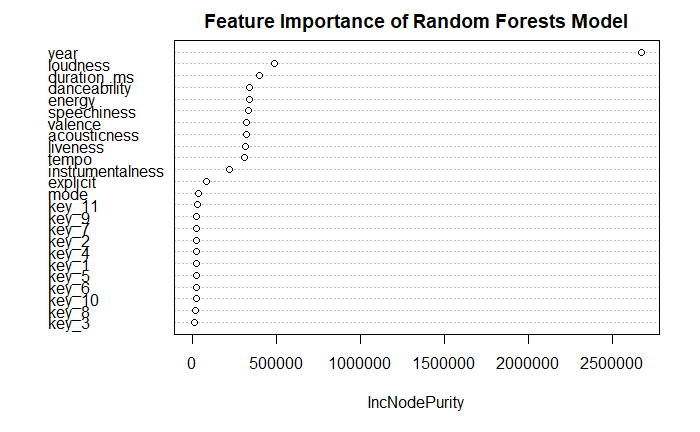

```r
# Feature Explanations Plot
varImpPlot(predict_set.rf_train,main="Feature Importance of Random Forests Model")
```

#### Train a Gradient Boosting Model to predict popularity

Prepare a different training set for this Gradient Boosting model

```r
# For this model, we split the popularity column away from the dataset and explicitly specify it as the y-variable.
train_x = data.matrix(predict_set.train[, !names(predict_set.train) %in% c("popularity")])
train_y = predict_set.train$popularity

test_x = data.matrix(predict_set.test[, !names(predict_set.test) %in% c("popularity")])
test_y = predict_set.test$popularity


predict_set.xgb_train = xgb.DMatrix(data = train_x, label = train_y)
predict_set.xgb_test = xgb.DMatrix(data = test_x, label = test_y)

# Train an XGBoost model
# To avoid overfitting, we use relatively shallow trees (max-depth = 3), set early stopping rounds to 3, eta=0.10, and number of training rounds to 600
predict_set.xgb_model = xgboost(data = predict_set.xgb_train, max.depth = 3, nrounds = 600, early_stopping_rounds = 3,eta=0.10,nthread=3)
```

```
Will train until train_rmse hasn't improved in 3 rounds.
```

```r
# Get model details
print(predict_set.xgb_model)
```

```
##### xgb.Booster
raw: 400.6 Kb
call:
  xgb.train(params = params, data = dtrain, nrounds = nrounds,
    watchlist = watchlist, verbose = verbose, print_every_n = print_every_n,
    early_stopping_rounds = early_stopping_rounds, maximize = maximize,
    save_period = save_period, save_name = save_name, xgb_model = xgb_model,
    callbacks = callbacks, max.depth = 3, eta = 0.1, nthread = 3)
params (as set within xgb.train):
  max_depth = "3", eta = "0.1", nthread = "3", validate_parameters = "1"
xgb.attributes:
  best_iteration, best_msg, best_ntreelimit, best_score, niter
callbacks:
  cb.print.evaluation(period = print_every_n)
  cb.evaluation.log()
  cb.early.stop(stopping_rounds = early_stopping_rounds, maximize = maximize,
    verbose = verbose)
# of features: 24
niter: 600
best_iteration : 600
best_ntreelimit : 600
best_score : 8.207237
best_msg : [600]    train-rmse:8.207237
nfeatures : 24
evaluation_log:
```

| iter | train_rmse |
| --- | --- |
| 1 | 47.010811 |
| 2 | 42.487495 |
| 3 | 38.435833 |
| 4 | 34.808659 |
| 5 | 31.566555 |
| 6 | 28.671776 |
| 7 | 26.092276 |
| 8 | 23.798187 |
| 9 | 21.762997 |
| 10 | 19.962292 |

[output cut: 590 more lines]

Test model on predictions and get training errors

```r
# Get predictions
predictions.xgb = predict(predict_set.xgb_model, predict_set.xgb_test)
paste("RMSE:",Metrics::rmse(predict_set.test$popularity, predictions.xgb))
```

```
[1] "RMSE: 8.60153883993324"
```

```r
paste("MAE:",Metrics::mae(predict_set.test$popularity, predictions.xgb))
```

```
[1] "MAE: 6.57013288999663"
```

```r
paste("MASE:",Metrics::mase(predict_set.test$popularity, predictions.xgb))
```

```
[1] "MASE: 1.2967588940801"
```

We plot the original test set popularity against the predicted test set popularity

```r
x = 1:length(test_y)
plot(x, test_y, col = "red", type = "l")
lines(x, predictions.xgb, col = "blue", type = "l")
```

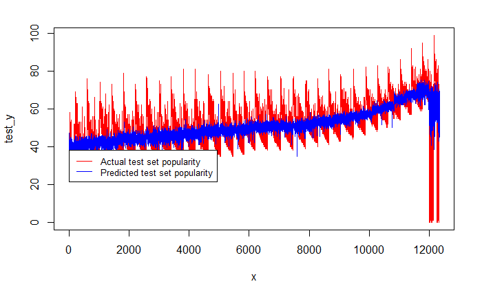

```r
legend(x = 1, y = 38,  legend = c("Actual test set popularity", "Predicted test set popularity"),
       col = c("red", "blue"), box.lty = 1, cex = 0.8, lty = c(1, 1))
```

We compute the feature importance matrix for this model as well.

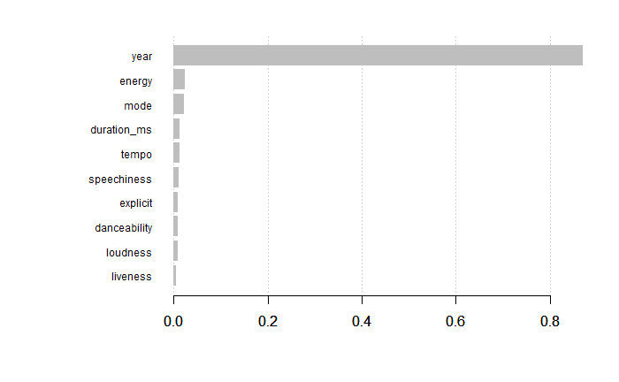

```r
# Compute feature importance matrix
names <- dimnames(data.matrix(predict_set.train[,-1]))[[2]]

importance_matrix <- xgb.importance(names, model = predict_set.xgb_model)
xgb.plot.importance(importance_matrix[1:10,])
```

##### Insights:

Since fitting a random forest model was promising for popularity prediction, we try to fit a Gradient Boosting Model as a similar decision-tree based model, but with a potentially better fit. Gradient Boosting is a set of decision trees that are built in an additive (ensemble-like) manner, by introducing weak learners to improve the shortcomings of existing weak learners. Gradient boosting is also done in a sequential manner, by combining results along the way. However, this makes it easy to overfit a Gradient Boosting model, and we have done various tuning of the parameters to avoid overfitting.

- The RMSE of the last training iteration of the model was 8.21, and the test RMSE was 8.60; this suggests that the model was not excessively overfit.
- With RMSE at 8.60 and MAE at 6.57, this gradient boosting model was not able to improve upon the the previous random forests model.
- Looking at the popularity predictions against the test set popularity plot, it seems like the model does poorly at predicting the songs at the extremes of the popularity scale over time.
- Looking at the feature importance plot, the gradient boosting model also relies mostly on year for its prediction. Other than year, energy, mode, and duration_ms are significant features that are predictive of popularity.

#### Use AutomML to train and search for a model that accurately predicts popularity

We use H2O (an AutoML library) to automatically train models and optimize hyperparameters to optimize for predicting popularity.

```r
# Initialize H2O engine
h2o.init()
```

```
 Connection successful!

R is connected to the H2O cluster:
    H2O cluster uptime:         2 days 10 hours
    H2O cluster timezone:       America/New_York
    H2O data parsing timezone:  UTC
    H2O cluster version:        3.32.0.1
    H2O cluster version age:    2 months
    H2O cluster name:           H2O_started_from_R_bohan_xvw355
    H2O cluster total nodes:    1
    H2O cluster total memory:   6.50 GB
    H2O cluster total cores:    8
    H2O cluster allowed cores:  8
    H2O cluster healthy:        TRUE
    H2O Connection ip:          localhost
    H2O Connection port:        54321
    H2O Connection proxy:       NA
    H2O Internal Security:      FALSE
    H2O API Extensions:         Amazon S3, Algos, AutoML, Core V3, TargetEncoder, Core V4
    R Version:                  R version 4.0.3 (2020-10-10)
```

```r
predict_set.h2o_train <- as.h2o(predict_set.train)
predict_set.h2o_test <- as.h2o(predict_set.test)
```

To reduce compute time, we train a maximum of 30 models.

```r
h2o_train.aml <- h2o.automl(y = "popularity", training_frame = predict_set.h2o_train, max_models = 30)
```

```
22:38:05.176: AutoML: XGBoost is not available; skipping it.
```

```r
lb <- h2o.get_leaderboard(h2o_train.aml)
# Print the model leaderboard (ranked by RMSE)
head(lb)
```

|  | model_id | mean_residual_deviance | rmse | mse | mae | rmsle |
| --- | --- | --- | --- | --- | --- | --- |
| 1 | StackedEnsemble_BestOfFamily_AutoML_20201208_223805 | 72.69033 | 8.525862 | 72.69033 | 6.523434 | 0.2357538 |
| 2 | StackedEnsemble_AllModels_AutoML_20201208_223805 | 72.71709 | 8.527432 | 72.71709 | 6.521619 | 0.2360285 |
| 3 | GBM_1_AutoML_20201208_223805 | 73.48369 | 8.572263 | 73.48369 | 6.550348 | 0.2379597 |
| 4 | GBM_2_AutoML_20201208_223805 | 73.61734 | 8.580055 | 73.61734 | 6.553386 | 0.2383986 |
| 5 | XRT_1_AutoML_20201208_223805 | 73.75329 | 8.587974 | 73.75329 | 6.602548 | 0.2312725 |
| 6 | GBM_3_AutoML_20201208_223805 | 73.77020 | 8.588958 | 73.77020 | 6.564426 | 0.2372111 |

Use the best model (leader model) to predict on the test set.

```r
predictions <- h2o.predict(h2o_train.aml@leader, predict_set.h2o_test)
```

Get details about the most accurate model.

```r
h2o_train.aml@leader
```

[output not shown]

Take all models in the leaderboard, and use each model to predict on the test set.

```r
perf_df<-data.frame(model_name=character(0),RMSE=numeric(0),MSE=numeric(0),MAE=numeric(0),RMSLE=numeric(0),mean_residual_deviance=numeric(0),r2=numeric(0))
mod_ids <- as_tibble(h2o_train.aml@leaderboard$model_id)
for(i in 1:6) {
  aml1 <- h2o.getModel(h2o_train.aml@leaderboard[i, 1]) # get model object in environment
  perf <- h2o.performance(aml1, predict_set.h2o_test)
  perf_df[nrow(perf_df) + 1,] = list(perf@metrics$model$name, perf@metrics$RMSE, perf@metrics$MSE, perf@metrics$mae, perf@metrics$rmsle, perf@metrics$mean_residual_deviance,  perf@metrics$r2)


}

# Print all performance metrics
perf_df
```

|  | model_name | RMSE | MSE | MAE | RMSLE | mean_residual_deviance | r2 |
| --- | --- | --- | --- | --- | --- | --- | --- |
| 1 | StackedEnsemble_BestOfFamily_AutoML_20201208_223805 | 8.508034 | 72.38664 | 6.535455 | 0.2274506 | 72.38664 | 0.4660559 |
| 2 | StackedEnsemble_AllModels_AutoML_20201208_223805 | 8.507913 | 72.38459 | 6.534702 | 0.2275526 | 72.38459 | 0.4660710 |
| 3 | GBM_1_AutoML_20201208_223805 | 8.546418 | 73.04125 | 6.558953 | 0.2287981 | 73.04125 | 0.4612273 |
| 4 | GBM_2_AutoML_20201208_223805 | 8.564381 | 73.34863 | 6.563113 | 0.2292302 | 73.34863 | 0.4589600 |
| 5 | XRT_1_AutoML_20201208_223805 | 8.584401 | 73.69194 | 6.616959 | 0.2258473 | 73.69194 | 0.4564276 |
| 6 | GBM_3_AutoML_20201208_223805 | 8.579991 | 73.61624 | 6.581976 | 0.2293761 | 73.61624 | 0.4569860 |

```r
NA
```

##### Insights:

After training up to 30 models using an AutoML library that searches for optimal model architectures and tunes model hyperparameters, the best leaderboard model was only able to slightly improve forecasting accuracy (RMSE at 8.51, MAE at 6.54). The best performing model was a complex stacked ensemble model comprised of 5 base models (1 deep learning model, 2 distributed random forests, 1 gradient boosting model, and 1 generalized linear model). Looking at the performance metric leaderboard on the test set, the low r2 of these models (46.66% for the most accurate model) implies that the given independent variables are still, in aggregate a poor predictor of popularity. In other words, these independent variables do not seem to capture the entire variance of popularity, and thus there may be other predictors of song popularity that are not captured within the dataset (i.e. frequency of the song’s appearance in Twitter tweets).

## **Performance Comparisons and Conclusions**

##### Predicting Song Feature Trends:

Using these values above for the predicted median value for the most popular songs, for each feature, music curators and record labels can predict which “sounds” will be most popular in the future. This information can then be used for future decision making with respect to which artists to sign and which sounds to push.

##### Predicting Song Popularity:

Based on our chosen error metrics for model selection (RMSE, MAE, MASE), the best model that minimized these error metrics on the testing set was the Stacked Ensemble model trained via AutoML, with RMSE: 8.51 and MAE: 6.54. Our random forests model came at a close second with RMSE: 8.54, MAE: 6.58, followed by our gradient boosting model with RMSE: 8.60 and MAE: 6.57. Finally, our multiple linear regression model had RMSE: 9.02 and MAE: 6.93.

The significance in the error metrics improvement from the linear model to the random forests model suggests that we were able to capture some significant non-linearities in the data. Nevertheless, despite the complexity of the Stacked Ensemble model, the improvement in prediction accuracy was minimal when compared to the random forests model. This suggests that the independent variables in the data do not fully capture the variance expressed in the dependent popularity variable. From the t-stat of the linear model and the feature importance plot of both the random forests and gradient boosting model, it was observed that year was by far the most significant factor used to explain popularity, which was observed as the average popularity of any song was highly correlated to the recency of the song’s release date. Moreover, the low r2 in the leaderboard of the AutoML models and the 47% variance explained in the random forests model supports the fact that the independent variables used do not fully explain the popularity of a song. To further improve this prediction accuracy, we would suggest looking into alternative datasets (e.g. Twitter/Instagram mentions of a given song name) to supplement this dataset and potentially improve prediction accuracy. Finally, predicting song popularity to a very precise extent may be inherently difficult because of the various human influences/factors that dictates the popularity of any given song. Nonetheless, we have built a very strong foundation for predicting song popularity and have learned many lessons along the way.